# Dataset Review — Twitter & Amazon

Antes de entrenar cualquier modelo conviene auditar los datos. Este notebook responde tres preguntas por dataset:

1. **¿Están balanceadas las clases?** — Un desbalance severo sesga el entrenamiento.
2. **¿Qué señal textual hay?** — Vocabulario, longitud y bigramas revelan la dificultad del problema.
3. **¿Qué ruido hay que limpiar?** — Duplicados, textos vacíos y tokens irrelevantes.

> **Cómo ejecutar:** `Kernel › Restart & Run All`

## 1. Twitter — `bdstar/twitter-sentiment-analysis`

Dataset de tweets en inglés etiquetados como **positive** o **negative**. Es el corpus principal para las prácticas de clasificación de sentimientos de texto corto.

**Características del dominio:**

- Texto muy corto (≤ 280 caracteres)
- Ruido específico: menciones, hashtags, URLs, abreviaturas
- Lenguaje informal, ironía, emojis

|  | split | total | positive | negative | neutral | % pos |
| --- | --- | --- | --- | --- | --- | --- |
| 0 | train | 3142209 | 1561453 | 1570031 | 10725 | 49.7 |
| 1 | test | 1600000 | 800000 | 800000 | 0 | 50.0 |

### 1.1 Distribución de clases

Un **desbalance severo** entre clases hace que el modelo aprenda a predecir siempre la mayoritaria. Con 90 % de ejemplos positivos, un clasificador trivial alcanza 90 % de accuracy sin aprender nada útil.

> **Qué buscamos:** ratio cercano a 1:1, o documentar el desbalance para compensarlo con `class_weight='balanced'` en sklearn o `pos_weight` en PyTorch.

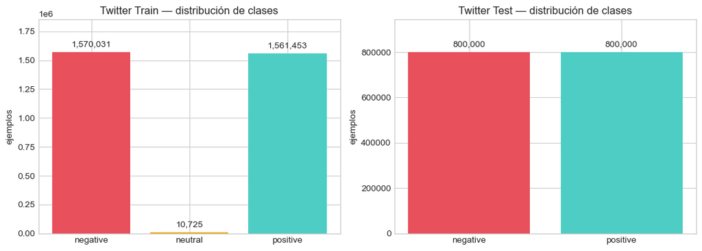

### 1.2 Longitud de los textos

La longitud media determina el `max_length` óptimo al tokenizar. Truncar muy corto pierde información; truncar muy largo infla el coste computacional.

- **Histograma:** distribución general del corpus
- **Boxplot por clase:** ¿diferente longitud implica diferente sentimiento?
- **p95:** buen candidato para `max_length` — cubre el 95 % de los textos sin overhead innecesario

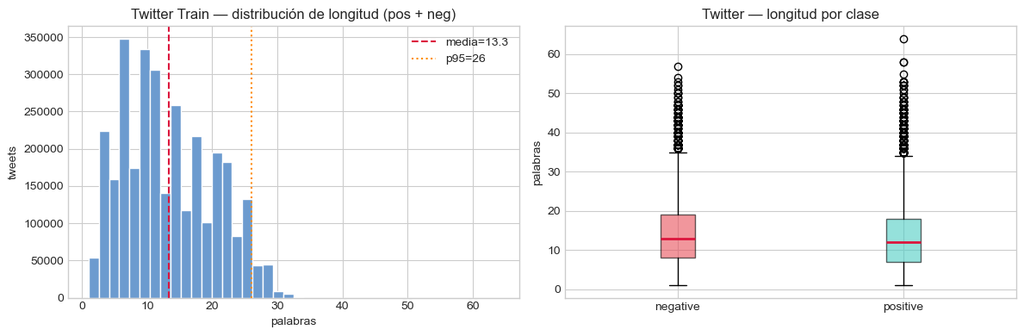

```
media=13.3  mediana=12  p95=26  max=64
```

### 1.3 Tokens especiales (ruido de Twitter)

Twitter introduce tokens que **no aportan semántica generalizable** pero consumen espacio en el vocabulario y pueden introducir sesgos (mencionar a un usuario famoso puede correlacionar con negatividad sin ser señal real).

| Token | Impacto | Tratamiento habitual |
| --- | --- | --- |
| `@mención` | Sesgo por usuario | → `<USER>` |
| `#hashtag` | Ruido de vocabulario | Quitar `#` o → `<HASHTAG>` |
| URL | Sin semántica | → `<URL>` |

> El preprocesamiento en `preprocessing.py` ya aplica parte de esta normalización.

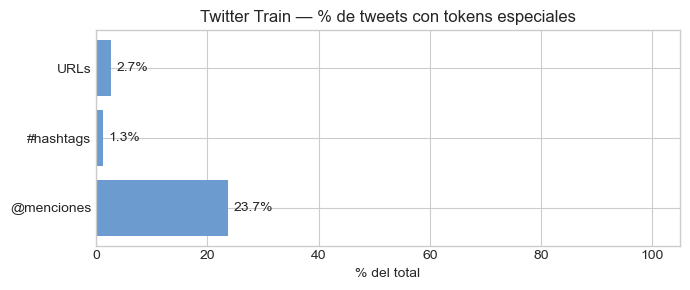

### 1.4 Palabras más frecuentes

Los **unigramas** muestran vocabulario discriminativo: palabras que aparecen mucho en una clase pero poco en la otra son señales directas para el clasificador.

**Limitación:** pierden el contexto. *not happy* contiene `happy`, igual que *very happy*. Los bigramas (siguiente gráfico) capturan esta diferencia.

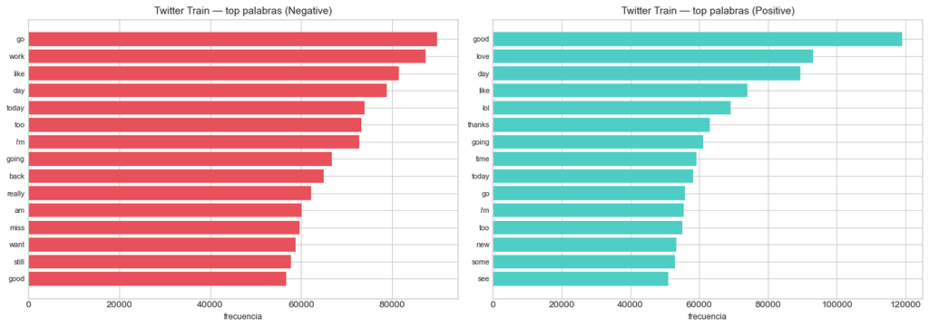

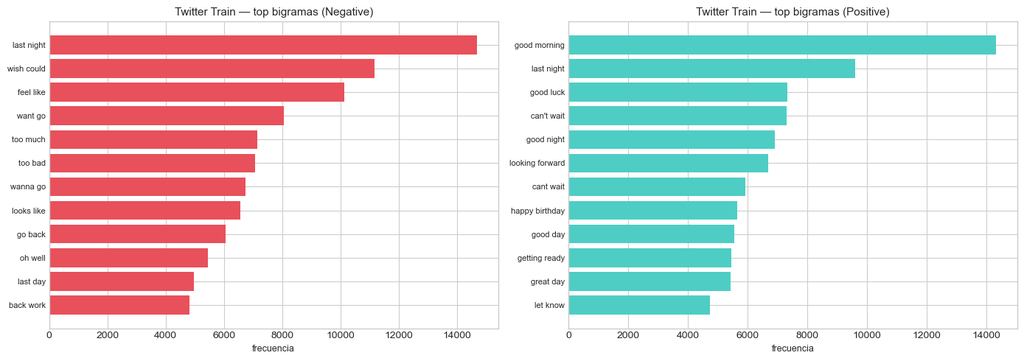

### 1.5 Separabilidad léxica con VADER

VADER asigna un score compuesto en [−1, +1] usando un léxico con reglas de contexto (negaciones, mayúsculas, signos de puntuación). Visualizar su distribución por clase revela:

- **¿Qué tan separables son las clases?** Si las distribuciones se solapan mucho, un léxico solo no alcanzará alta accuracy.
- **¿Dónde falla VADER?** Textos negativos con score ≈ 0 son los casos difíciles: ironía, jerga, ausencia de palabras de sentimiento explícitas.

Los umbrales punteados (±0.05) son los que usa VADER por defecto para clasificar positivo/negativo/neutro.

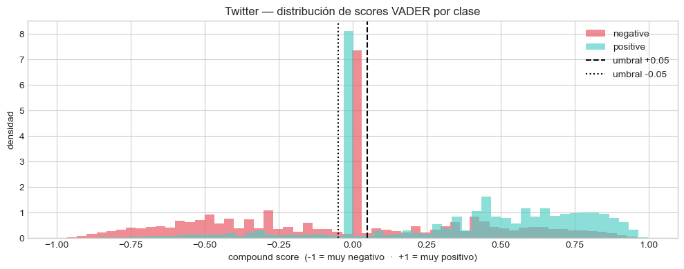

```
negative    media=-0.039  std=0.438
positive    media=+0.333  std=0.394
```

### 1.6 Calidad del dataset

Antes de entrenar hay que cuantificar el ruido estructural:

- **Duplicados:** el modelo puede memorizar ejemplos repetidos, inflando el accuracy de validación artificialmente.
- **Textos vacíos:** no aportan señal y pueden generar errores en el pipeline.
- **Textos muy cortos:** con < 3 palabras hay poca señal útil.

```
── Calidad Twitter Train ────────────────────────────
  Total                : 3,142,209
  Duplicados           : 74,116  (2.36%)
  Vacíos               : 0
  Muy cortos (<3 pal.) : 54,303
```

|  | text | label |
| --- | --- | --- |
| 0 | is upset that he can't update his Facebook by ... | negative |
| 1 | @Kenichan I dived many times for the ball. Man... | negative |
| 2 | my whole body feels itchy and like its on fire | negative |
| 3 | @nationwideclass no, it's not behaving at all.... | negative |
| 4 | @Kwesidei not the whole crew | negative |
| 5 | Need a hug | negative |
| 6 | @LOLTrish hey long time no see! Yes.. Rains a... | negative |
| 7 | @Tatiana_K nope they didn't have it | negative |

## 2. Amazon — `McAuley-Lab/Amazon-Reviews-2023` (corpus local)

Reseñas de productos con rating de 1 a 5 estrellas. A diferencia de Twitter:

|  | Twitter | Amazon |
| --- | --- | --- |
| Longitud | Muy corta (≤ 280 chars) | Párrafos completos |
| Clases | 2 (pos / neg) | 5 ratings |
| Ruido | Menciones, hashtags, URLs | HTML residual, emojis |
| Lenguaje | Informal, ironía | Más formal, descriptivo |

**Estrategia de etiquetado usada en el curso:**

- `rating ≤ 2` → negativo (0)
- `rating ≥ 4` → positivo (1)
- `rating = 3` → descartado (ambiguo)

```
Reviews: 1,000  |  Columnas: ['text', 'rating', 'title', 'asin']
Ratings disponibles: [1, 2, 3, 4, 5]
```

|  | text | rating | title | asin |
| --- | --- | --- | --- | --- |
| 0 | First & most offensive: they reek of gasoline ... | 3 | Smells like gasoline! Going back! | B083NRGZMM |
| 1 | These didn’t work. Idk if they were damaged in... | 1 | Didn’t work at all lenses loose/broken. | B07N69T6TM |
| 2 | I love these. They even come with a carry case... | 5 | Excellent! | B01G8JO5F2 |
| 3 | I was searching for a sturdy backpack for scho... | 5 | Great laptop backpack! | B001OC5JKY |

### 2.1 Distribución de ratings

Amazon tiene un **sesgo positivo conocido** (distribución en forma de J): la mayoría son 5★ porque los compradores satisfechos tienen más motivación para reseñar. Esto complica el balanceo al binarizar.

> **Implicación:** al construir el split binario hay que submuestrear positivos o usar `class_weight` para compensar la diferencia.

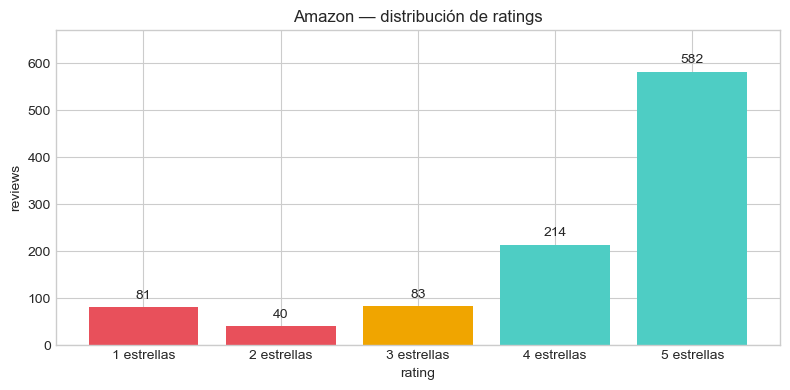

```
Negativas (<=2): 121
Neutras   (=3):  83
Positivas (>=4): 796
```

### 2.2 Longitud de reviews por rating

> **Riesgo:** si no se controla, el modelo puede aprender a clasificar por longitud en lugar de por contenido. Truncar a un `max_length` uniforme mitiga este problema.

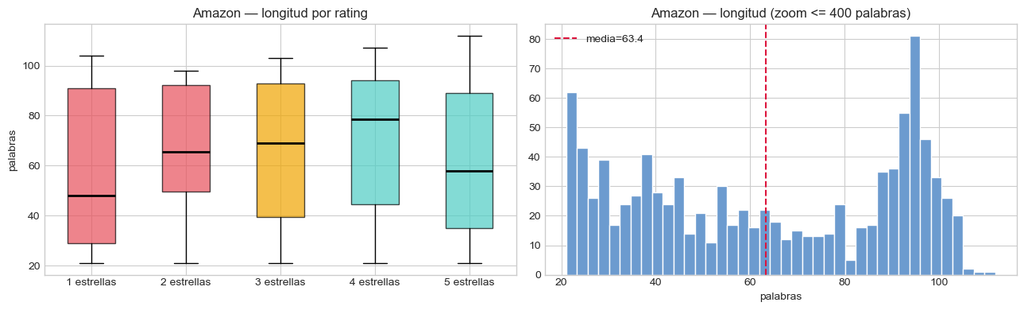

```
        mean  median  max
rating
1       56.7    48.0  104
2       65.1    65.5   98
3       67.0    69.0  103
4       71.0    78.5  107
5       60.9    58.0  112
```

### 2.3 Vocabulario por sentimiento

A diferencia de Twitter, el vocabulario de Amazon es más formal y descriptivo. Los bigramas capturan frases de evaluación de producto (*highly recommend*, *waste of money*) que son señales muy fuertes y apenas aparecen si se miran solo unigramas.

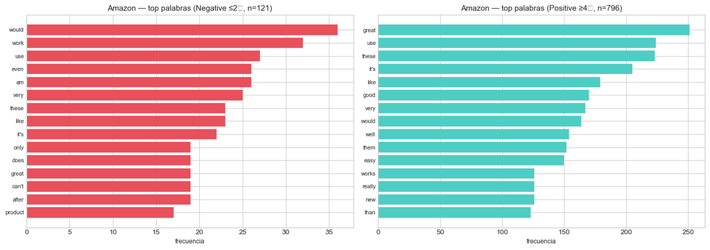

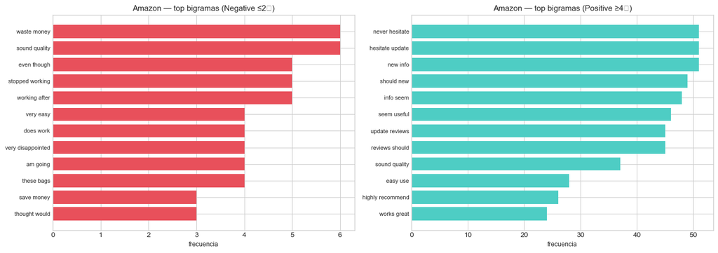

### 2.4 Calidad del dataset

```
── Calidad Amazon ───────────────────────────────────
  Total                : 1,000
  Duplicados           : 2
  Vacíos               : 0
  Muy cortos (<5 pal.) : 0
```

|  | rating | title | text |
| --- | --- | --- | --- |
| 521 | 5 | The perfect cleaner for your unsightly, smudgy... | Try them. You will love them. Guaranteed.<br /... |
| 737 | 5 | Better deal than in stores! | I paid $42 for this on Amazon. Best Buy has th... |
| 740 | 5 | Sturdy | I had a smaller holler to put my kindle tablet... |
| 660 | 4 | VERY SOLIDLY BUILT; LOTS OF FEATURES | PROS: Very study and solid, carrying strap wi... |
| 411 | 5 | star wars record player | I purchased this for my son-in-law for christm... |

## 3. Resumen comparativo

Tabla con las métricas clave de ambos datasets para referencia al diseñar los pipelines de entrenamiento.

| Metrica | Twitter (train) | Amazon |
| --- | --- | --- |
| Total ejemplos | 3,142,209 | 1,000 |
| Clases | 2 (pos / neg) | 5 ratings (binarizable) |
| Longitud media (palabras) | 13.3 | 63.4 |
| Longitud mediana | 12 | 62 |
| Percentil 95 de longitud | 26 | 100 |
| Duplicados | 74,116 | 2 |
| Vocabulario unico | 1,291,472 | 8,071 |
| % con @menciones | 23.7% | - |
| % con #hashtags | 1.3% | - |
| % con URLs | 2.7% | - |